# Association rules

Movie recommender systems

94101448

2018-07-19 15:28:41

> با استفاده از داده نظرهای فیلم به سوالات زیر پاسخ دهید.

۱. آماره های زیر را بیابید. الف. محبوب ترین فیلم کدام است؟ ب. بیشترین نظرات درباره چه فیلمی داده شده است؟ پ. منفورترین فیلم کدام است؟ ت. تعداد فیلم های ساخته شده در هر سال ث. در هر سالی مردم به چه ژانری علاقه مند بوده اند.

```r
library(readr)
library(dplyr)
movie=read_delim('/Users/macbook/Documents/university/term6/data analysis/HW/hw_12/ml-10M100K/movies.dat',
                 delim = "::",
                 col_names = c('MovieId','NA','Title','NA','Genres'))
movie=movie %>% select(1,3,5)

tag=read_delim('/Users/macbook/Documents/university/term6/data analysis/HW/hw_12/ml-10M100K/tags.dat',
               delim="::",
               col_names = c('userId','NA',"MovieID","NA","Tag","Timestap"))
tag=tag %>% select(1,3,5)

rating=read_delim('/Users/macbook/Documents/university/term6/data analysis/HW/hw_12/ml-10M100K/ratings.dat',
                  delim="::",
               col_names = c('userId','NA',"MovieID","NA","Rating","Timestap"))
#part a
library(dplyr)
#to increase accuracy we filter movies that were voted less than
# half of total number of votes average
rating %>% group_by(MovieID) %>%
  summarise(mean_rate=mean(Rating,na.rm=TRUE),count=n()) %>%
  filter(count > 0.5*mean(count,na.rm=TRUE)) %>%
  mutate(rank=as.integer(rank(-mean_rate)))->q1

#first we choose movies with highest rating average
popular_movie=q1$MovieID[which(q1$rank==1)]
print("most popular movie")
```

```
## [1] "most popular movie"
```

```r
movie$Title[which(movie$MovieId==popular_movie)]
```

```
## [1] "Shawshank Redemption, The (1994)"
```

```r
#partb
rating %>% group_by(MovieID) %>%
  summarise(count=n()) ->q1b
id=q1b$MovieID[which.max(q1b$count)]
print("most rated movie")
```

```
## [1] "most rated movie"
```

```r
movie$Title[which(movie$MovieId==id)]
```

```
## [1] "Pulp Fiction (1994)"
```

```r
#part c
library(dplyr)
#to increase accuracy we filter movies that were voted less than
# half of total number of votes average
rating %>% group_by(MovieID) %>%
  summarise(mean_rate=mean(Rating,na.rm=TRUE),count=n()) %>%
  filter(count > 0.5*mean(count,na.rm=TRUE)) %>%
  mutate(rank=as.integer(rank(mean_rate)))->q1

#first we choose movies with lowest rating average
popular_movie=q1$MovieID[which(q1$rank==1)]
print("most disliked movie")
```

```
## [1] "most disliked movie"
```

```r
movie$Title[which(movie$MovieId==popular_movie)]
```

```
## [1] "Battlefield Earth (2000)"
```

```r
#part d
library(stringr)
movie$year=str_sub(movie$Title,-5,-2)
#year of some of the movies osnt mentioned
#we stick with the above method (although it has some error due to mentioned problem)
#and we filter the error when ever year is important to us
movie_filt=movie %>% arrange(desc(year))
movie_filt=movie_filt[417:9811,]
freq=movie_filt %>% group_by(year) %>%
  summarise(count=n()) %>% na.omit()
print("number of  movies made per year")
```

```
## [1] "number of  movies made per year"
```

```r
freq$year[which.max(freq$count)]
```

```
## [1] "2002"
```

```r
#parte
movie_filt$MovieID=movie_filt$MovieId
cmplt=merge(movie_filt %>% select(-MovieId),rating)
cmplt %>% group_by(year,Genres) %>% summarise(mean_rate=mean(Rating,na.rm=TRUE))->qe
qe=na.omit(qe)

print("favorite genre of the year")
```

```
## [1] "favorite genre of the year"
```

```r
qe=qe %>%
  group_by(year) %>%
  mutate(rank=rank(-mean_rate)) %>%
  filter(rank==1)
# qe is the desired table: year-genre
```

۲. ژانر فیلم ها را استخراج نمایید. سپس آماره های زیر را استخراج نمایید. الف. نمودار ستونی تعداد فیلم های هر ژانر ب. نمودار همبستگی ژانرها پ. متوسط امتیاز به هر ژانر ت. دوران طلایی فیلم سازی

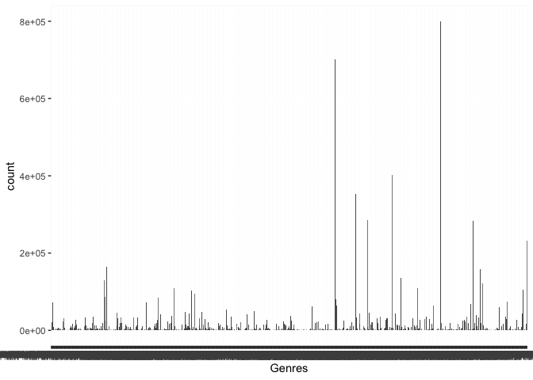

```r
#part a
library(tidyr)
library(highcharter)
genre=cmplt %>% select(Genres)
genre=genre %>% group_by(Genres) %>%
  mutate(count=n()) %>% distinct()
library(ggplot2)

ggplot(genre)+geom_bar(aes(x=Genres,y=count),stat='identity')
```

```r
cmplt %>% select(MovieID,Genres) %>% distinct()->data_genre
data_genre=data_genre %>% mutate(id=c(1:dim(data_genre)[1]))
gen=cmplt %>% select(Genres) %>% distinct()
movie_genre=matrix(FALSE,nrow=dim(data_genre)[1],ncol=dim(gen))
colnames(movie_genre)=c(1:716)

for (i in c(1:dim(movie_genre)[2])) {
  temp=data_genre %>% filter(Genres==gen[i,1]) %>% select(id)
  movie_genre[unlist(temp),i]=TRUE
}
sum(movie_genre==TRUE)
```

```
## [1] 9334
```

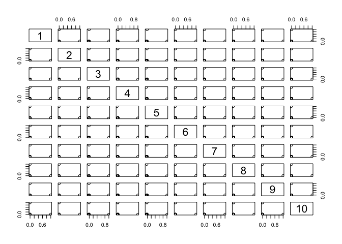

```r
cor=cor(movie_genre)
pairs(cor[c(1:10),c(1:10)])
```

```r
# chon hajm kheili ziad bud ye bakhsh kami ra rasm kardim
library(car)
```

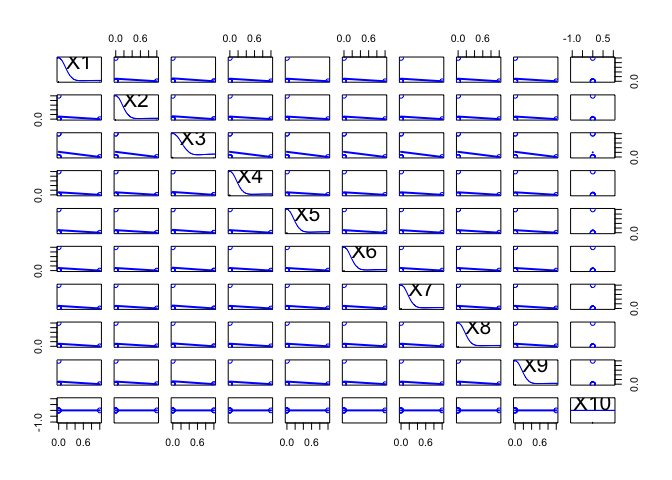

```r
scatterplotMatrix(movie_genre[c(1:10),c(1:10)])
```

```r
library(ggplot2)
library(ggcorrplot)
library(tidyr)
library(dplyr)
```

```r
#part c
print("mean rate of genre")
```

```
## [1] "mean rate of genre"
```

```r
cmplt %>% group_by(Genres) %>%
  summarise(mean_rate=mean(Rating,na.rm = TRUE))->q2c
```

```r
#part d
print("golden age ")
```

```
## [1] "golden age "
```

```r
library(highcharter)
cmplt %>% select(year,Rating)->temp
temp %>% group_by(year) %>%
  mutate(count=n()) %>%
  mutate(rate_mean=mean(Rating,na.rm=TRUE))->temp

temp %>% select(-Rating) %>%distinct() ->temp
temp %>% arrange(desc(year))->temp
temp=temp[1:95,]
temp=temp[-c(9,10),]
temp %>% hchart("line",hcaes(x=year,y=count))
```

[interactive chart not shown]

```r
#1991-1995 increasing trend in number of  movies
temp %>% hchart("line",hcaes(x=year,y=rate_mean))
```

[interactive chart not shown]

```r
#1920-1970 rating balaei daran k montabegh bar wiki pedia ast
```

۳. نمودار ابر لغات را بر حسب کلمات عنوان فیلم ها رسم نمایید.

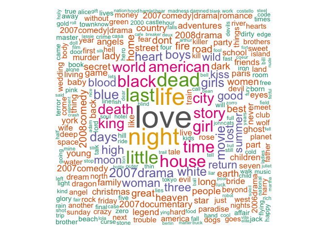

```r
library(stringr)
library(wordcloud)
library(tm)
library(RColorBrewer)
names=movie %>% select(Title)
words=str_sub(names$Title, 1,-7)

final = words %>%
  str_replace_all("\"","") %>%
  str_replace_all("[[:punct:]]","") %>%
  str_split(pattern = "\\s") %>%
  unlist() %>%
  str_to_lower() %>%
  removeWords(., stopwords('en')) %>%
  str_trim() %>%
  table() %>%
  as.data.frame(stringsAsFactors = F)

colnames(final) = c("word","count")

final = final %>% arrange(desc(count)) %>%
  filter(nchar(word)>3)

wordcloud(final$word,final$count, random.order = FALSE, colors=brewer.pal(8, "Dark2"))
```

۴. با استفاده از قوانین همبستگی یک توصیه گر برای فیلم ها بسازید. شبیه ترین فیلم ها به لیست زیر را پیدا کنید.

- Castle in the Sky (1986)
- Cast Away (2000)
- No Country for Old Men (2007)
- Memento (2000)

```r
# bedune asscociation rule
find=movie %>% filter(str_detect(Title,'Castle in the Sky'))
id=rating %>% group_by(userId) %>% filter(Rating>4) %>% filter(MovieID==6350) %>% select(userId) %>% .$userId

other=rating %>% filter(userId %in% id) %>% filter(Rating>4) %>%
  group_by(MovieID) %>% summarise(sum=sum(Rating),mean=mean(Rating)) %>%
  arrange(desc(sum),desc(mean))

movie$Title[which(movie$MovieId==5618)]
```

```
## [1] Spirited Away (Sen to Chihiro no kamikakushi) (2001)
## 9768 Levels: 'Round Midnight (1986) ... xXx
```

```r
###
find=movie %>% filter(str_detect(Title,'Cast Away'))
id=rating %>% group_by(userId) %>% filter(Rating>4) %>% filter(MovieID==4022) %>% select(userId) %>% .$userId

other=rating %>% filter(userId %in% id) %>% filter(Rating>4) %>%
  group_by(MovieID) %>% summarise(sum=sum(Rating),mean=mean(Rating)) %>%
  arrange(desc(sum),desc(mean))

movie$Title[which(movie$MovieId==318)]
```

```
## [1] Shawshank Redemption, The (1994)
## 9768 Levels: 'Round Midnight (1986) ... xXx
```

```r
###
find=movie %>% filter(str_detect(Title,'No Country for Old Men'))
id=rating %>% group_by(userId) %>% filter(Rating>4) %>% filter(MovieID==51372) %>% select(userId) %>% .$userId

other=rating %>% filter(userId %in% id) %>% filter(Rating>4) %>%
  group_by(MovieID) %>% summarise(sum=sum(Rating),mean=mean(Rating)) %>%
  arrange(desc(sum),desc(mean))
for (i in c(1:36)) {
  movie$Title[which(movie$MovieId==other$MovieID[i])]
  movie$Title
}

###
find=movie %>% filter(str_detect(Title,'Memento'))
id=rating %>% group_by(userId) %>% filter(Rating>4) %>% filter(MovieID==4226) %>% select(userId) %>% .$userId

other=rating %>% filter(userId %in% id) %>% filter(Rating>4) %>%
  group_by(MovieID) %>% summarise(sum=sum(Rating),mean=mean(Rating)) %>%
  arrange(desc(sum),desc(mean))

movie$Title[which(movie$MovieId==296)]
```

[output not shown]

```
## [1] Pulp Fiction (1994)
## 9768 Levels: 'Round Midnight (1986) ... xXx
```

۵. تمرین سخت: در گیت هاب برای خود اکانت درست کنید. همه تمرین های خود را آنجا بارگذاری کنید! و لینک آن را ارسال نمایید.

۶. پنج انتقاد از درس و نحوه تدریس را بیان کنید.

۷. پنج پیشنهاد برای بهتر شدن درس بیان کنید.

۸. سه موضوع آماری جدید برای جایگزینی در سرفصل ها پیشنهاد دهید.

۹. سه داده جالب برای کار در کلاس پیشنهاد دهید.

۱۰. چهار نکته مهمی که در کلاس یاد گرفتید را بیان کنید.